# L3: Variables, Strings, Numbers, and Conditional Statements

Bogdan G. Popescu

bogdan.popescu@johncabot.edu

John Cabot University

## Introduction

We will now get down to business and learn the basics or Python.

Create a new Quarto Document. Delete all the irrelevant information. Put your name in the preamble.

Make sure that you replace `/opt/anaconda3/bin/python` with your python path:

- see the address of your Python interpreter in R (also see lecture 1)

````markdown
---
title: "Lab3"
author: "Your Name"
date: "2024-11-05"
format: html
toc: true
embed-resources: true
---

# Introduction

Today we learn Python.

```{r}
reticulate::use_python("/opt/anaconda3/bin/python", required = TRUE)
```
````

[interactive chart not shown]

## Introduction

This is how we add Python chunks and text

````markdown
---
title: "Lab3"
author: "Your Name"
date: "2024-11-05"
format: html
toc: true
embed-resources: true
---

# Introduction

Today we learn Python.

```{r}
reticulate::use_python("/opt/anaconda3/bin/python", required = TRUE)
```

The following is a Python chunk.

```{python filename="Python"}
#Here goes the Python Code
```

The following is an R chunk.

```{r filename="R"}
#Here goes the R Code
```
````

[interactive chart not shown]

## Introduction

In this section, we will learn how to store information in variables.

We will explore different data types, including strings and numerical data types.

A **variable** holds at least one value. For example, the following are variables

```
Python
```

```python
message = "Hello"
print(message)
```

```
Hello
```

```
Python
```

```python
number = 3
print(number)
```

```
3
```

```
Python
```

```python
boolean = True
print(boolean)
```

```
True
```

## Variables

```
Python
```

```python
message = "Hello"
number = 3
boolean = True
```

All these variables hold individual values: Hello, 3, TRUE

The value Hello is a string object in Python.

The value 3 is a numeric object.

The value TRUE is a Boolean object.

## Variables

```
Python
```

```python
message = "Hello"
number = "3"
boolean = "True"
```

What type of variables are `number` and `boolean`?

They are both strings because they have quotes

## Variables

### Naming Rules

Variables can contain letters, numbers, and underscores.

```
Python
```

```python
message = "Hello"

message3 = "Hello"

message_3 = "Hello"
```

Variables cannot start with a number, e.g., “3message”.

A variable cannot have two unconnected words, e.g., “message 3”

Variables should not use Python keywords as variable names: e.g.: “False”, “None”, “True”, “and”, etc.

## Variables

### Exercise

Store “Hello World” in a variable called “message” and print it.

```
Python
```

```python
message = "Hello World"
print(message)
```

```
Hello World
```

## Variables

### Strings

Strings are sets of characters.

Either single or double quotes can contain strings

```
Python
```

```python
message1 = "Hello"
message2 = 'Hello'
```

Let us now print the messages:

```
Python
```

```python
print(message1)
```

```
Hello
```

```
Python
```

```python
print(message2)
```

```
Hello
```

## Variables

### Combining Strings

We can easily combine or concatenate strings.

```
Python
```

```python
message1 = "Hello,"
message2 = "world!"
combined_message = message1 + " " + message2
print(combined_message)
```

```
Hello, world!
```

## Variables

### String Indexing

**Indexing** allows you to access individual characters in a string.

Python strings are **zero-indexed**: the first character is at index 0, the second at index 1, and so on.

You can use positive or negative indices:

- **Positive Indexing**: Starts from the beginning (left to right).
- **Negative Indexing**: Starts from the end (right to left).

```
Python
```

```python
message = "Hello"
first_char = message[0]
first_char
```

```
'H'
```

## Variables

### String Indexing

**Indexing** allows you to access individual characters in a string.

Python strings are **zero-indexed**: the first character is at index 0, the second at index 1, and so on.

You can use positive or negative indices:

- **Positive Indexing**: Starts from the beginning (left to right).
- **Negative Indexing**: Starts from the end (right to left).

```
Python
```

```python
last_char = message[-1]
last_char
```

```
'o'
```

## Variables

### String Indexing

We can also extract more than one character.

```
Python
```

```python
message = "Hello"
first_2char = message[:2]
first_2char
```

```
'He'
```

```
Python
```

```python
last_2char = message[-2:]
last_2char
```

```
'lo'
```

## Variables

### String Slicing

**String slicing** is a way to extract a portion (substring) of a string by specifying a range of indices.

- A string comprises individual characters, each with its **own index**.
- **Syntax**: `string[start:end]`
  - **start**: The index where slicing begins (inclusive)
  - **end**: The index where slicing ends (exclusive)

```
Python
```

```python
# Define a string
message = "Hello"

# Slice from index 0 to 3 (exclusive)
substring = message[0:3]
substring
```

```
'Hel'
```

## Variables

### String Slicing

**Important Points**

- **Indexing starts at 0**: The first character has an index of `0`, the second character `1`, and so on.
- **End is exclusive**: the slicing stops just **before** the end index.

**Advanced Slicing: Omitting Start or End**

- `text[:5]` - From the beginning to index 5 (exclusive).
- `text[6:]` - From index 6 to the end of the string

## Variables

### String Slicing

**Why Use String Slicing?**

To extract specific parts of a string (e.g. first few characters or a substring)

```
Python
```

```python
# Define a string
message = "Hello"
# Slice from index 0 to 3 (exclusive)
substring = message[0:3]
print(substring)
```

```
Hel
```

We can also extract the first and the last character:

```
Python
```

```python
message[0]
```

```
'H'
```

```python
message[-1]
```

```
'o'
```

## String Operations

### Finding Substrings

We can see if specific strings are within our strings.

We can do that in the following way:

```
Python
```

```python
sentence = "John, Anna, and Emma are in this class"
john_present = 'John' in sentence
print(john_present)
```

```
True
```

```
Python
```

```python
sentence = "John, Anna, and Emma are in this class"
john_present = 'Marc' in sentence
print(john_present)
```

```
False
```

## String Operations

### Replacing Substrings

We can easily replace a string by using `.replace`

```
Python
```

```python
sentence = "John, Anna, and Emma are in this class"
new_sentence = sentence.replace('John', 'Marc')
print(new_sentence)
```

```
Marc, Anna, and Emma are in this class
```

## String Operations

### Counting Substrings

We can count how many times a substring can be found within a bigger string in the following way:

```
Python
```

```python
sentence = "John, Anna, and Emma are in this class. John enjoys this class"
no_john = sentence.count('John')
print(no_john)
```

```
2
```

## String Operations

### Splitting strings

Strings can be split into substrings when a repeated character separates them.

The split function returns a set of substrings.

```
Python
```

```python
sentence = "John, Anna, and Emma are in this class"
new_sentence = sentence.split(' ')
print(new_sentence)
```

```
['John,', 'Anna,', 'and', 'Emma', 'are', 'in', 'this', 'class']
```

Notice that the punctuation is still there.

## String Operations

### Strings: Lower Case to Upper Case and the Opposite

We can turn lower case strings into upper case strings:

```
Python
```

```python
group = "John, Anna, Emma, Mark"
uppercase_group = group.upper()
print(uppercase_group)
```

```
JOHN, ANNA, EMMA, MARK
```

We can turn upper-case strings into lower strings:

```
Python
```

```python
lowercase_group = uppercase_group.lower()
print(lowercase_group)
```

```
john, anna, emma, mark
```

## String Operations

### Strings: Lower Case to Upper Case and the Opposite

We can turn lower case strings into upper case strings:

We can also have every word start with an uppercase.

```
Python
```

```python
cap_group = uppercase_group.title()
print(cap_group)
```

```
John, Anna, Emma, Mark
```

## String Operations

### Removing Whitespace

The `.strip()` method removes leading and trailing whitespace (spaces, tabs, or newlines).

```
Python
```

```python
message = "   Hello"
stripped_message = message.strip()
print(stripped_message)
```

```
Hello
```

## String Operations

### Finding Substrings

The `.find()` method searches for the first occurrence of a substring within a string and returns its index. If the substring is not found, it returns `-1`

```
Python
```

```python
sentence = "Python is fun!"
index = sentence.find("fun")
print(index)
```

```
10
```

Here is why the index is 10

| Character | P | y | t | h | o | n |  | i | s |  | f | u | n | ! |
| --- | --- | --- | --- | --- | --- | --- | --- | --- | --- | --- | --- | --- | --- | --- |
| Index | 0 | 1 | 2 | 3 | 4 | 5 | 6 | 7 | 8 | 9 | 10 | 11 | 12 | 13 |
| ———– | — | — | — | — | — | — | — | — | — | — | — | — | — | — |

## String Operations

### Strings and Numbers

We can mix strings and numbers in the following way.

```
Python
```

```python
number = 23
print("My favorite number is " + str(number) + ".")
```

```
My favorite number is 23.
```

## Strings

### Dealing with Whitespace

The most common white space characters are spaces, tabs, and newlines.

- **No Spaces**

```
Python
```

```python
print("Hello World!")
```

```
Hello World!
```

- **Spaces (Tabs)**

`\t` is the standard way to mark tabs in Python.

```
Python
```

```python
print("\tHello World!")
```

```
    Hello World!
```

```
Python
```

```python
print("Hello\t world!")
```

```
Hello    world!
```

## Strings

### Dealing with Whitespace

We can split two lines using `\n`

- **Spaces (New Lines)**

We can move strings on a new line.

```
Python
```

```python
print("Hello\n world!")
```

```
Hello
 world!
```

## Strings

### Exercise

Store the following quote in a variable: “Never succumb to the temptation of bitterness.”

Add another variable: “Martin Luther King once said:”

Print the two variables together. Your response should look like:

```
"Martin Luther King once said: 'Never succumb to the temptation of bitterness.'"
```

## Numbers

### Calculations

Dealing with numbers is straightforward in Python.

```
Python
```

```python
#Addition
print(1+2)
```

```
3
```

```
Python
```

```python
#Subtraction
print(1-2)
```

```
-1
```

```
Python
```

```python
#Multiplication
print(1*2)
```

```
2
```

## Numbers

### Calculations

Dealing with numbers is straightforward in Python.

```
Python
```

```python
#Division
print(1/2)
```

```
0.5
```

```
Python
```

```python
#Exponentiation
print(1**2)
```

```
1
```

## Numbers

### Floating-Point numbers

Dealing with numbers is straightforward in Python.

```
Python
```

```python
#"floor” division (rounds down to nearest whole number)
print(1//2)
```

```
0
```

Floating-point numbers refer to any number with a decimal point.

```
Python
```

```python
print(0.1+0.1)
```

```
0.2
```

## Numbers

### Exercise 1

Write a program that prints the result of one calculation for each of the basic operations: addition, subtraction, multiplication, division, and exponentiation.

Start with a=10 and b=5.

Then, create new objects: addition, subtraction, multiplication, division, exponentiation.

## Numbers

### Exercise 1

Write a program that prints out the results of one calculation for each of the basic operations: addition, subtraction, multiplication, division, and exponents.

```
Python
```

```python
#Defining values
a = 10
b = 5
#Performing the calculation
addition = a + b
subtraction = a - b
multiplication = a * b
division = a/b
exponentiation = a**b
```

## Numbers

### Exercise 1

Write a program that prints out the results of one calculation for each of the basic operations: addition, subtraction, multiplication, division, and exponents.

```
Addition: a + b = 15
```

```
Subtraction: a - b = 5
```

```
Multiplication: a * b = 50
```

```
Division: a / b = 2.0
```

```
Exponentiation: a**b = 100000
```

## Logical Operations

### Booleans

A Boolean is a logical data type with only true or false values.

This is what they look like in Python.

```
Python
```

```python
x = True
y = False
```

This is what happens when I print them.

```
Python
```

```python
print(x)
```

```
True
```

```python
print(y)
```

```
False
```

## Logical Operations

### Booleans

This is what happens after we perform the following operation.

True and True is True

```
Python
```

```python
x and x
```

```
True
```

True and False is False

```
Python
```

```python
x and y
```

```
False
```

## Logical Operations

### Booleans

This is what happens after we perform the following operation.

False and False is False

```
Python
```

```python
y and y
```

```
False
```

## Logical Operations

### Booleans

We can also obtain booleans in the following way:

```
Python
```

```python
3 > 1
```

```
True
```

```
Python
```

```python
3 >= 1
```

```
True
```

```
Python
```

```python
3 < 1
```

```
False
```

```
Python
```

```python
z = 1
z == 1
```

```
True
```

## Logical Operations

### Booleans

We can have even more complex Booleans.

```
Python
```

```python
grade = 68
grade_desired = 80
type_student = "exchange student"

(type_student == 'exchange student') and (grade < grade_desired)
```

```
True
```

## Logical Operations

### Booleans

To check if a variable is Boolean or not, we can perform:

```
Python
```

```python
x = True
type(x)
```

```
<class 'bool'>
```

This is different from:

```
Python
```

```python
y = 1
type(y)
```

```
<class 'int'>
```

```python
z1 = 1.0
type(z1)
z2 = '1'
type(z2)
```

```
<class 'float'>
```

```
<class 'str'>
```

## Logical Operations

### Expressions

An expression is a code that is executed upon evaluation.

For example, `x=1` is not an expression that is evaluated but instead declared.

The following, for example, is an expression:

```
Python
```

```python
- 3 + 5*(120/12)
```

```
47.0
```

We can concatenate strings:

```
Python
```

```python
# Concatenation of strings
3 * 'Hello!'
```

```
'Hello!Hello!Hello!'
```

## Logical Operations

### Expressions vs. Statements

It is essential to clarify the distinction between expressions and statements.

**Expression** - piece of code that **produces a value** when evaluated.

The following example produces 28

```
Python
```

```python
# Concatenation of strings
3 + 5 * (10 / 2)
```

```
28.0
```

**Statement** - a piece of code that **performs an action** but doesn’t necessarily return a value.

Example: `x = 10` assigns the value `10` to the variable x

## Logical Operations

### Exercises

What is the value of w?

```
Python
```

```python
x = 12
y = -1
z = 0

w = x*2 - y + 1**z
```

What is the value of the variable c?

```
Python
```

```python
a = 'Hello'
b = 'World'
c = a[:4] + '_' + b
```

## Logical Operations

### Exercises

What is the value of the variable c?

```
Python
```

```python
a = 1
b = 2.0
c = '7'

d = str((3*a + b/0.5) / int(c))
```

## Conditional Statements

### Introduction

- Conditional statements allow us to execute specific code based on certain conditions.
- They are fundamental in controlling the flow of a program.
- Common types of conditional statements in Python:
  - `if`
  - `elif`
  - `else`

## Conditional Statements

### Syntax of Conditional Statements

This is what the syntax of conditional statements looks like:

```python
if condition:
    # code to execute if condition is True
elif another_condition:
    # code to execute if another_condition is True
else:
    # code to execute if all conditions are False
```

**Example: Simple If Statement**

```
Python
```

```python
age = 18

if age >= 18:
    print("You are eligible to vote.")
```

```
You are eligible to vote.
```

## Conditional Statements

### Syntax of Conditional Statements

**Example: If-Else Statement**

This code checks the temperature. If it’s over 25, it prints that it’s a hot day; otherwise, it prints a different message.

```
Python
```

```python
temperature = 30

if temperature > 25:
    print("It's a hot day!")
else:
    print("It's a pleasant day!")
```

```
It's a hot day!
```

## Conditional Statements

### Syntax of Conditional Statements

**Example: If-Elif-Else Statement**

The following code evaluates the score and prints the corresponding grade based on the defined ranges.

```
Python
```

```python
score = 85

if score >= 90:
    print("Grade: A")
elif score >= 80:
    print("Grade: B")
elif score >= 70:
    print("Grade: C")
else:
    print("Grade: D")
```

```
Grade: B
```

## Conditional Statements

### *elif* statements

We can use `elif` statements when we want to check multiple conditions that are dependent on each other.

In that case, only one block should be executed among multiple conditions

The `elif` block will be checked if the preceding `if` or `elif` conditions are false.

Example:

```python
if condition1:
    # This block will execute if condition1 is true
elif condition2:
    # This block will execute if condition1 is false and condition2 is true
elif condition3:
    # This block will execute if condition1 and condition2 are false and condition3 is true
```

## Other Operations

### Difference `if` and `elif`

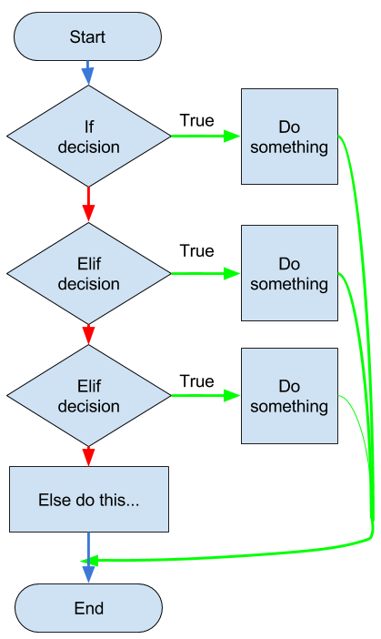

## Other Operations

### Difference `if` and `elif`

**Use `if`**:

- when you want to check multiple conditions independently of each other
- When multiple conditions can be true simultaneously, and you want to execute the corresponding blocks for all true conditions.

```python
if condition1:
    # This block will execute if condition1 is true
if condition2:
    # This block will execute if condition2 is true (independently of condition1)
```

## Other Operations

### Difference `if` and `elif`

**Use `elif`**:

- when you want to check multiple conditions dependent on each other
- when only one block should be executed among multiple conditions
- the `elif` block will be checked only if the preceding `if` and `elif` conditions were false

```python
if condition1:
    # This block will execute if condition1 is true
elif condition2:
    # This block will execute if condition1 is false and condition2 is true
elif condition3:
    # This block will execute if condition1 and condition2 are false and condition3 is true
```

## Other Operations

### Example use `if` vs. `elif`

- Using `if` (independent conditions)

```python
weather = "rainy"
if weather == "rainy":
    print("Take an umbrella.")
if weather == "windy":
    print("Wear a windbreaker.")
if weather == "sunny":
    print("Wear sunglasses.")
```

```
Take an umbrella.
```

- if the weather is rainy, it will print “Take an umbrella.”
- The other conditions will still be checked, but only the block for the true condition will be executed.

## Other Operations

### Example use `if` vs. `elif`

- Using `elif` (dependent conditions)

```python
weather = "rainy"
if weather == "rainy":
    print("Take an umbrella.")
elif weather == "windy":
    print("Wear a windbreaker.")
elif weather == "sunny":
    print("Wear sunglasses.")
```

```
Take an umbrella.
```

- only the block for the first condition will execute
- if `weather` is “rainy”, it will print “Take an umbrella.” and then skip all subsequent `elif` blocks.

## Other Operations

### Example use `if` vs. `elif`

- Using `elif` (dependent conditions)
- Here is when `elif` gets executed

```python
weather = "windy"
if weather == "rainy":
    print("Take an umbrella.")
elif weather == "windy":
    print("Wear a windbreaker.")
elif weather == "sunny":
    print("Wear sunglasses.")
```

```
Wear a windbreaker.
```

- Once again, the `elif` block will be checked only if the preceding `if` and `elif` conditions were false

## Other Operations

### The `else` statement

The `else` statement can define a block of code to be executed if none of the preceding `if` or `elif` conditions are true.

It is a catch-all for any cases not covered by previous conditions.

Thus, use `else` to specify a code block if the preceding conditions are false.

```python
weather = "rainy"
if weather == "rainy":
    print("Take an umbrella.")
elif weather == "windy":
    print("Wear a windbreaker.")
elif weather == "sunny":
    print("Wear sunglasses.")
else:
    print("Check weather & dress well.")
```

## Other Operations

### The `else` statement

```
Python
```

```python
weather = "rainy"
if weather == "rainy":
    print("Take an umbrella.")
elif weather == "windy":
    print("Wear a windbreaker.")
elif weather == "sunny":
    print("Wear sunglasses.")
else:
    print("Check weather & dress well")
```

```
Take an umbrella.
```

- The `if` statement checks if the weather is “rainy”. If true, it prints “Take an umbrella.”.
- The first `elif` checks if the weather is “windy”. If true, it prints “Wear a windbreaker.” but only if the previous `if` condition was false.
- The second `elif` checks if the weather is “sunny”. If true, it prints “Wear sunglasses.” but only if all previous conditions were false.

## Other Operations

### The `else` statement

```
Python
```

```python
weather = "rainy"
if weather == "rainy":
    print("Take an umbrella.")
elif weather == "windy":
    print("Wear a windbreaker.")
elif weather == "sunny":
    print("Wear sunglasses.")
else:
    print("Check weather & dress well")
```

```
Take an umbrella.
```

- The `else` statement catches any other weather conditions not covered by the if and elif statements and prints “Check weather & dress well”.

## Other Operations

### Exercise:

Write a program using `if`, `elif`, and `else` that prints a letter grade for students.

Here are the rules:

- If the score is 90 or above, the grade is ‘A’
- If the score is 80 or above but less than 90, the grade is ‘B’
- If the score is 70 or above but less than 80, the grade is ‘C’
- If the score is 60 or above but less than 70, the grade is ‘D’
- If the score is less than 60, the grade is ‘F’

Let’s start with `grade=92`

## Other Operations

### Exercise:

This is how we can write this:

```
Python
```

```python
grade = 92

if grade >= 90:
  print("A")
elif grade >= 80:
  print("B")
elif grade >= 70:
  print("C")
elif grade >= 60:
  print("D")
else:
  print("F")
```

```
A
```

## Other Operations

### Exercise:

Note that you could potentially write this only with `if` statements.

This, however, would require checking each condition independently.

This approach is less efficient as it does not take advantage of the mutually exclusive nature of the `elif` conditions.

## Other Operations

### Exercise:

What if the grade was 72?

## Other Operations

### Exercise:

What if the grade was 72?

```
Python
```

```python
grade = 72

if grade >= 90:
  print("A")
elif grade >= 80:
  print("B")
elif grade >= 70:
  print("C")
elif grade >= 60:
  print("D")
else:
  print("F")
```

```
C
```

## Conclusion

**Understanding Logical Operations:**

- Logical operations are fundamental in programming and allow for decision-making based on conditions.

**Key Takeaways:**

- Expressions are evaluated to produce values.
- Variables store data and reference objects.
- Conditional statements (`if`, `elif`, `else`) control the flow of the program.

**Importance of Structure**

- Using conditions optimizes code by ensuring only relevant conditions are evaluated.